# Multivariate Analysis

Taylor Bonar & Satvik Ajmera

```r
library(tswge)
library(arrow)
library(lubridate)
library(tidyverse)

train = read_parquet("data/btc-train.parquet")
test.short = read_parquet("data/btc-test-short.parquet")
test.long = read_parquet("data/btc-test-long.parquet")

names(train)[1] <- "unix_time"
names(test.short)[1] <- "unix_time"
names(test.long)[1] <- "unix_time"
```

```r
# Clean into human-readable dates
train <- train %>% mutate(timestamp = as_datetime(unix_time))
test.short <- test.short %>% mutate(timestamp = as_datetime(unix_time))
test.long <- test.long %>% mutate(timestamp = as_datetime(unix_time))
```

# EDA

We are interested in identifying variables that impact BTC’s Open price (Y) (variable Open in train)

We will avoid using variables such as Close, Low, & High to avoid data leakage and redundancy. * Close is what we are essentially using with a lag 1 in an AR previously.

This leaves us with remaining variables to forecast the Open price for BTC: * Count (X_1) – the number of trades taking place this minute * Volume (X_2) – The number of cryptoasset units traded during the minute * VWAP (X_3) – The volume weighted average price for the minute * Target (X_4) – 15 minute residualized returns

Let’s plot the data

```r
library(ggplot2)
library(dplyr)
```

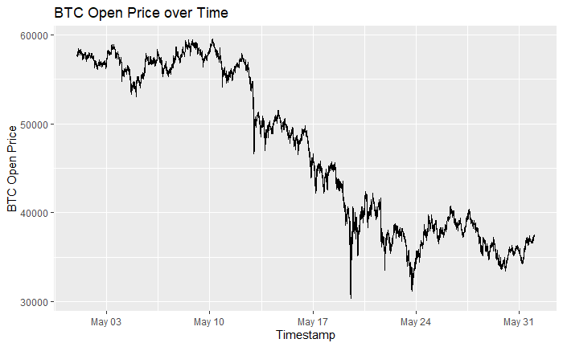

```r
ggplot(train, aes(x=timestamp, y=Open)) +
  geom_line() +
  xlab("Timestamp") +
  ylab("BTC Open Price") +
  ggtitle("BTC Open Price over Time")
```

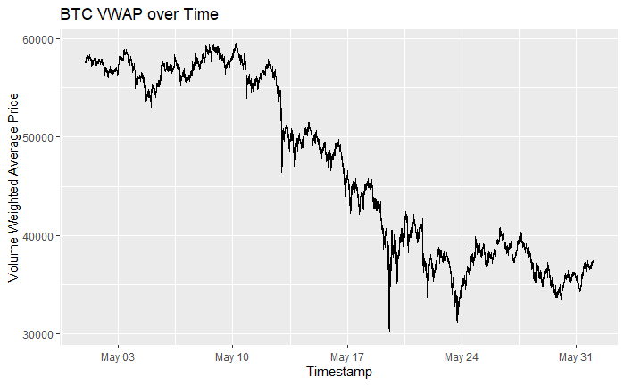

```r
ggplot(train, aes(x=timestamp, y=VWAP)) +
  geom_line() +
  xlab("Timestamp") +
  ylab("Volume Weighted Average Price") +
  ggtitle("BTC VWAP over Time")
```

VWAP may be serially correlated to Open as they have similar structure. This may provide data leakage and may need to be removed.

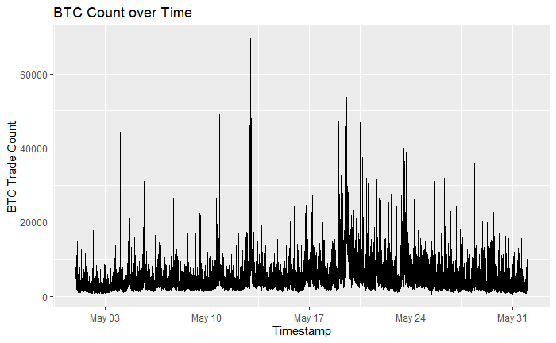

```r
ggplot(train, aes(x=timestamp, y=Count)) +
  geom_line() +
  xlab("Timestamp") +
  ylab("BTC Trade Count")  +
  ggtitle("BTC Count over Time")
```

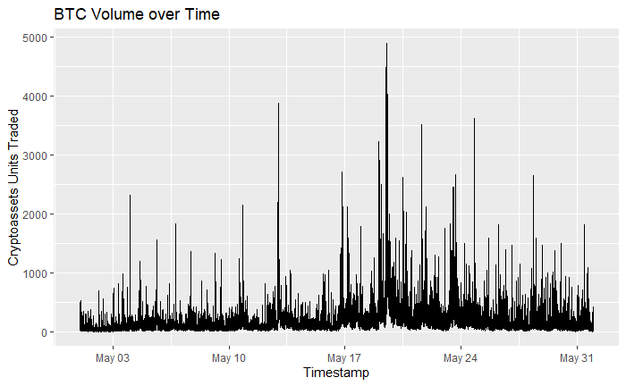

```r
ggplot(train, aes(x=timestamp, y=Volume)) +
  geom_line() +
  xlab("Timestamp") +
  ylab("Cryptoassets Units Traded") +
  ggtitle("BTC Volume over Time")
```

The Volume and Count may be serially correlated structurally

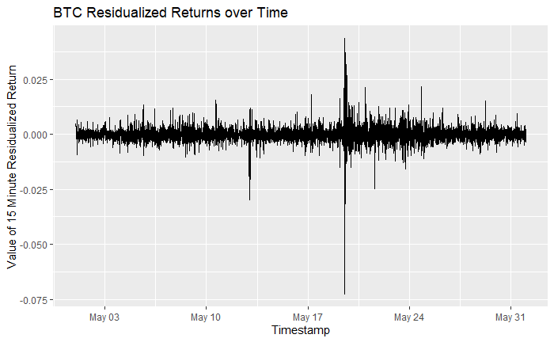

```r
ggplot(train, aes(x=timestamp, y=Target)) +
  geom_line() +
  xlab("Timestamp") +
  ylab("Value of 15 Minute Residualized Return") +
  ggtitle("BTC Residualized Returns over Time")
```

The Residualized Return (Target) has a higher frequency as we already knew. This really is a moving average pass-through of the data that we discovered in our EDA. However, it does look serially correlated with some peaks in the data, but structurally is different.

For now we’ll remove the VWAP variable due to data leakage, and use the remaining 3 variables.